# t-tests and regression analysis

# Difference in average cross-sectional area in high- and low responders

## Introduction

Haun et al. (2019) conducted their study on 30 trained men who performed a 6 weeks resistance training intervention. Two groups were formed based on training outcome measures, where the top and bottom third of the data set were assigned to a high- (*n* = 10) and low-responder group (*n* = 10), respectively. The goal of the study was to examine if high responders would experience greater increases in myonuclear accretion as well as biomarkers related to ribosome biogenesis, androgen signaling, mTORc1 signaling, and mitochondrial biogenesis relative to low responders.

Bamman et al. (2007) have found robust increases in muscle fiber cross-sectional area in extreme responders relative to non-responders following 16 weeks of training. The goal of this report is to compare the average cross-sectional area at T1 between high- (HIGH) and low responders (LOW) from Haun et al. (2019), to investigate if there are any differences between high- and low responders prior to a training intervention. We are going to do this with a simple t-test, and then compare the result to a regression model.

#### Null hypothesis

> There is no difference (*p* > 0.05) in average cross-sectional area at T1 between HIGH and LOW

#### Alternative hypothesis

> The average cross-sectional area at T1 is significantly (*p* < 0.05) greater in HIGH compared to LOW

## Methods

An independent, two sample t-test was used to compare the average cross-sectional area at T1 between the two groups. The significance level was set to *p* < 0.05. A regression model was also used to fit the data, with the two groups as predictors, and the average cross-sectional area at T1 as the dependent variable. Tests to check for constant variance, normal residuals and problematic observations were performed. No problematic observations were found, so we can safely use all the observations in the analysis

## Results

#### Regression model

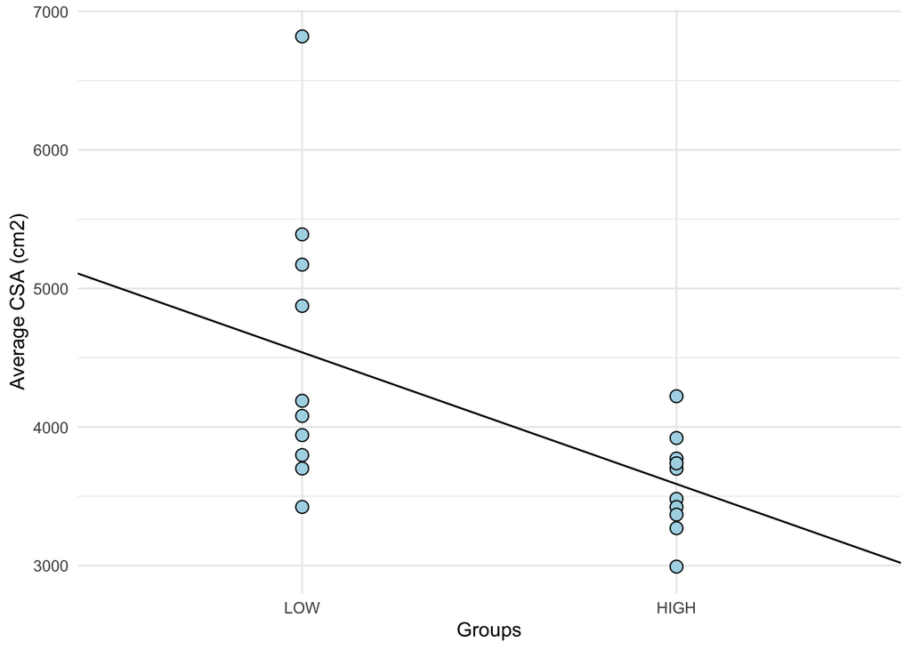

Figure 1: Results from a regression model with average cross-sectional area at T1 as the dependent variable and CLUSTER (HIGH and LOW) as the independent variable

Table 1: Results from a regression model with average cross-sectional area at T1 as the dependent variable and CLUSTER (HIGH and LOW) as the independent variable

|  | Estimate | SE | t-statistic | p-value |
| --- | --- | --- | --- | --- |
| (Intercept) | 4538.6 | 244.4 | 18.57 | 0.0000 |
| CLUSTERHIGH | -950.1 | 345.6 | -2.75 | 0.0132 |

#### t-test

The average cross-sectional area was 3588.4 cm<sup>2</sup> at T1 in HIGH, and 4538.6 cm<sup>2</sup> at T1 in LOW. The difference between the groups was -950.1 cm<sup>2</sup> (95% CI: [224.03, 1676.26], *t*(18) = 2.75, *p* = 0.013). The SE was 345.62.

## Discussion

We compared the results from the t-test and regression model, and found that the two testes produce the same results. To find the estimated mean for HIGH using the regression model, we take the estimate of LOW, minus the estimate of HIGH (4538.571 - 950.143 = 3588.428). We then get the same estimated mean as when using the t-test. When we use the regression model to calculate the 95 percent confidence intervals, we get the same result as the t-test. The results of the t-statistic, p-value and standard error are also the same using both testes.

Regarding the results, we can reject the null hypothesis that states that “there is no difference (*p* > 0.05) in average cross-sectional area at T1 between HIGH and LOW,” as *p* = 0.013. We can reject the null hypothesis with some certainty as the confidence interval do not contain 0 (95% CI: [224.03, 1676.26]).

The alternative hypothesis that states that “the average cross-sectional area at T1 is significantly (*p* < 0.05) greater in HIGH compared to LOW” can also be rejected, as the average cross-sectional area is greater in LOW compared to HIGH.

The findings from Haun et al. (2019) therefore suggests that low responders have a greater average cross-sectional area than high responders before starting a training intervention.

## References

Bamman, Marcas M., John K. Petrella, Jeong-su Kim, David L. Mayhew, and James M. Cross. 2007. “Cluster Analysis Tests the Importance of Myogenic Gene Expression During Myofiber Hypertrophy in Humans.” *Journal of Applied Physiology* 102 (6): 2232–9.

Haun, C. T., C. G. Vann, C. B. Mobley, S. C. Osburn, P. W. Mumford, P. A. Roberson, M. A. Romero, et al. 2019. “Pre-training Skeletal Muscle Fiber Size and Predominant Fiber Type Best Predict Hypertrophic Responses to 6 Weeks of Resistance Training in Previously Trained Young Men.” *Front Physiol* 10: 297.